# XML Vignette

Ryan McGovern and Steve Sortijas

June 6, 2019

# Introduction

## XML Data

In this project we use R to process and conduct exploratory data analysis on a publicly available XML dataset. XML, or Extensible Markup Language, is an open standard markup language that is designed to carry data and to enable compatibility. Unlike HTML, it uses tags which are user-defined and new tags can be created as new data is added without redefining existing tags. XML data is highly portable because it is stored in plain text, using a common standard which is not hardware or software dependent. XML is widely used in the development of document formats and industry data standards. This project uses XML data from Data.gov.

## Processing XML Data in R

In this vignette we will use the “XML” package for parsing and processing XML data. Another package called “xml2” is also available for managing XML and HTML data. Both packages are available in CRAN and xml2 is part of the tidyverse. The XML package is the better documented of the two packages and the list of functions in XML surpasses those than in xml2. For instance the XML package offers functions for transforming XML data to data frames and lists, whereas xml2 does not offer such functionality.

However, XML does have its particularities. Because it is well-documented, troubleshooting is often simpler. For instance, we use the httr package in calling the data because simply using the URL alone for this particular function resulted in an error. Whereas, for the xml2 package, using the URL alone did not result in an error.

## Dataset Information

For this vignette we will use a dataset consisting of mortality rates and life expectancy rates at birth by race and sex in the U.S. from 1900 to 2015. This data set is publicly available from the [CDC](https://data.cdc.gov/NCHS/NCHS-Death-rates-and-life-expectancy-at-birth/w9j2-ggv5).

This dataset consists of 1,044 observations with 5 variables relating to: year, race, sex, mortality, and average life expectancy. The dataset is in “long” form. Year, race, and sex are the groupings which contain values for mortality rates and average life expectancy rates. Year is inclusive of every year from 1900 to 2015. Race is a categorical variable consisting of: All Races, Black, and White. Although it is not explicit in CDC’s description of the data, we presume that the All Races category is Black and White combined. Sex is a categorical variable consisting of: Both Sexes, Female, and Male. Mortality rate (mortality), or age-adjusted death rates is a numerical variable representing the number deaths per 100,000. The link above describes in detail how mortality rates are calculated for various historical periods. Life expectancy rate (average_life_expectancy) is a numerical variable denominated in years. Per [CDC](https://www.cdc.gov/nchs/nvss/mortality/hist293.htm.), life expectancy data are available up to 2014 and are not consistently available for the black population before 1968. The average life expectancy variable is the only one which contains NAs.

The first contingency table below displays the number of observations for each numerical variable grouped by the race and sex. This shows that for average life expectancy, each group is missing one observation. The second contingency table confirms that the missing data is for 2015.

Count of Mortality and Life Expectancy Observations by Group

| Race | Sex | Mortality (n) | Life Expectancy (n) |
| --- | --- | --- | --- |
| All Races | Both Sexes | 116 | 115 |
| All Races | Female | 116 | 115 |
| All Races | Male | 116 | 115 |
| Black | Both Sexes | 116 | 115 |
| Black | Female | 116 | 115 |
| Black | Male | 116 | 115 |
| White | Both Sexes | 116 | 115 |
| White | Female | 116 | 115 |
| White | Male | 116 | 115 |

Count of Mortality and Life Expectancy Observations by Year

| Year | Mortality (n) | Life Expectancy (n) |
| --- | --- | --- |
| 2015 | 9 | 0 |

# Life expectancy

## Average Life Expectency by Gender and Decade

First we will explore the average life expectancy data. To help simplify our analysis, we will create a new variable called “decade” in order to group the years into their respective decades. We will then use this grouping to compare change in the numerical variables over time.

As discussed previously, we interpret the categorical value of “All Races” in the “race” variable to mean “black” and “white” combined. So for this first table, we will use only the “All Races” observations to show the average life expectancy rates by decade. This table is grouped by sex to highlight the different life expectancy rates between sexes. The bottom row of the table summarizes the differences in life expectancy rates between males and females during each decade.

Average Life Expectancy by Sex by Decade

|  | 1900 | 1910 | 1920 | 1930 | 1940 | 1950 | 1960 | 1970 | 1980 | 1990 | 2000 | 2010 |
| --- | --- | --- | --- | --- | --- | --- | --- | --- | --- | --- | --- | --- |
| Female | 51.09 | 53.72 | 59.51 | 63.42 | 67.87 | 72.34 | 73.78 | 76.17 | 78.11 | 79.09 | 80.11 | 81.16 |
| Male | 47.88 | 49.37 | 56.97 | 59.80 | 63.68 | 66.29 | 66.79 | 68.47 | 71.01 | 72.76 | 74.98 | 76.36 |
| Difference | 3.21 | 4.35 | 2.54 | 3.62 | 4.19 | 6.05 | 6.99 | 7.70 | 7.10 | 6.33 | 5.13 | 4.80 |

The average life expectancy trends upwards over time for both females and males for every decade. Females have a higher average life expectancy compared with males for every decade. From 1900 to 1970, the gap in life expectancy between the two groups more than doubles, with the peak difference in the 1970s (7.7 years difference). After 1970, The life expectancy gap between the two sexes then trends downward. In the tables below, we will explore the life expectancy data by race.

## Average Life Expectency by Gender and Decade Broken Out by Race

Average Life Expectancy by Sex and Decade: Black

| sex | 1900 | 1910 | 1920 | 1930 | 1940 | 1950 | 1960 | 1970 | 1980 | 1990 | 2000 | 2010 |
| --- | --- | --- | --- | --- | --- | --- | --- | --- | --- | --- | --- | --- |
| Female | 34.68 | 39.81 | 48.22 | 53.44 | 58.99 | 65.05 | 67.44 | 70.61 | 73.31 | 74.12 | 76.25 | 78.30 |
| Male | 31.89 | 36.66 | 46.96 | 50.48 | 55.91 | 60.39 | 61.15 | 61.99 | 64.71 | 65.75 | 69.57 | 72.22 |
| Difference | 2.79 | 3.15 | 1.26 | 2.96 | 3.08 | 4.66 | 6.29 | 8.62 | 8.60 | 8.37 | 6.68 | 6.08 |

Average life expectancy by Sex and Decade: White

| sex | 1900 | 1910 | 1920 | 1930 | 1940 | 1950 | 1960 | 1970 | 1980 | 1990 | 2000 | 2010 |
| --- | --- | --- | --- | --- | --- | --- | --- | --- | --- | --- | --- | --- |
| Female | 51.54 | 54.49 | 60.96 | 64.77 | 69.18 | 73.33 | 74.74 | 76.92 | 78.71 | 79.70 | 80.49 | 81.36 |
| Male | 48.26 | 49.95 | 58.22 | 61.05 | 64.65 | 67.09 | 67.61 | 69.29 | 71.72 | 73.59 | 75.49 | 76.64 |
| Difference | 3.28 | 4.54 | 2.74 | 3.72 | 4.53 | 6.24 | 7.13 | 7.63 | 6.99 | 6.11 | 5.00 | 4.72 |

Spread of Life Expectancy by Race

| Race | 1900 | 1910 | 1920 | 1930 | 1940 | 1950 | 1960 | 1970 | 1980 | 1990 | 2000 | 2010 |
| --- | --- | --- | --- | --- | --- | --- | --- | --- | --- | --- | --- | --- |
| Black | 2.79 | 3.15 | 1.26 | 2.96 | 3.08 | 4.66 | 6.29 | 8.62 | 8.60 | 8.37 | 6.68 | 6.08 |
| White | 3.28 | 4.54 | 2.74 | 3.72 | 4.53 | 6.24 | 7.13 | 7.63 | 6.99 | 6.11 | 5.00 | 4.72 |
| All Races | 3.21 | 4.35 | 2.54 | 3.62 | 4.19 | 6.05 | 6.99 | 7.70 | 7.10 | 6.33 | 5.13 | 4.80 |

## Visuals

The first plot looks at average life expectancy by sex for each decade of the dataset. This grouped bar graph demonstrates the trend towards higher life expectancy for both sexes as well as the persistent gap between male and female life expectancy, which widens and appears to currently be in a narrowing phase.

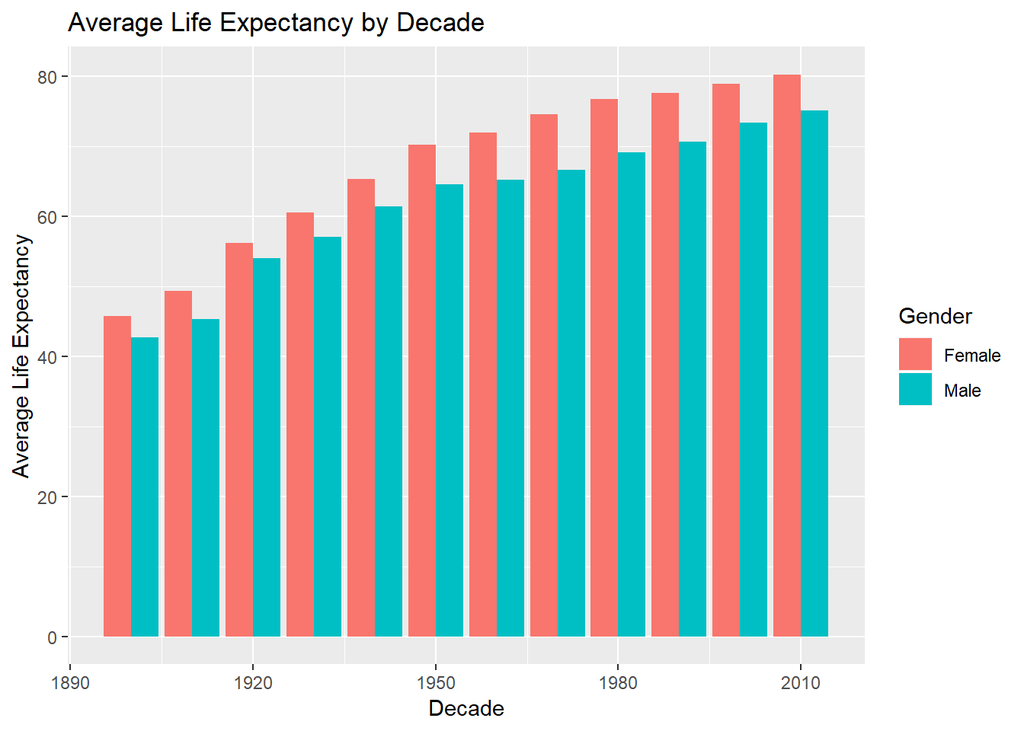

When stratified by race, the faceted bar graph below helps to see how life expectancy for black men and women have narrowed the a wide gap in life expectancy compared with white males and females since 1900. It also shows how the life expectancy gap between males and females has, in recent history, been larger for the black population compared with whites.

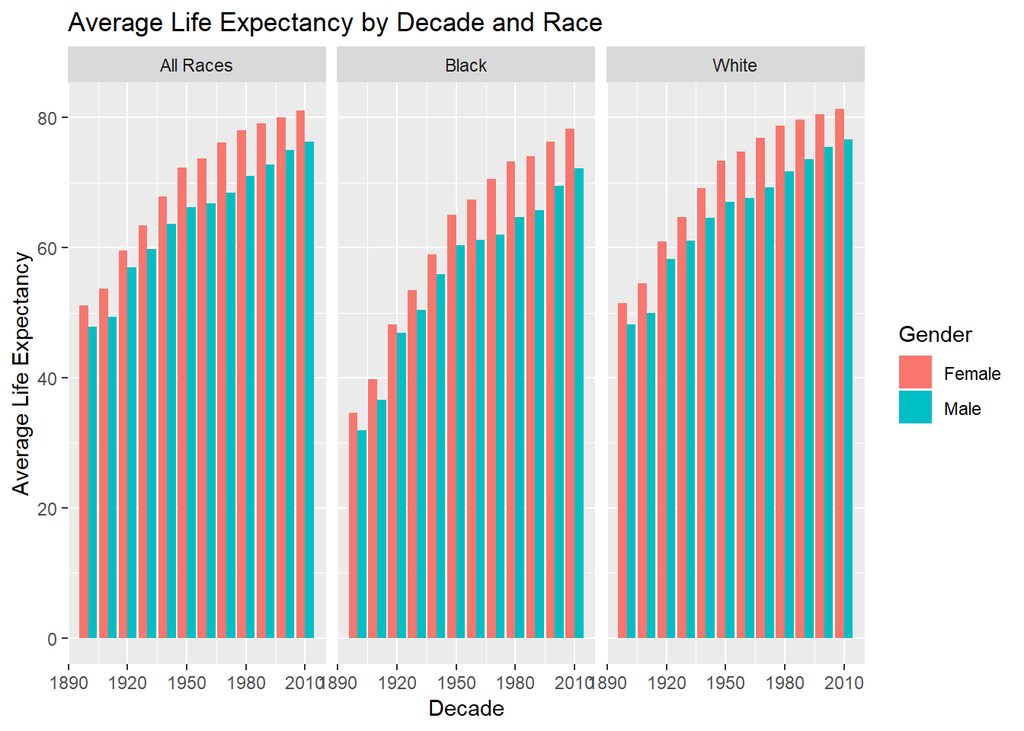

The boxplot below summarizes the life expectancy data by race and sex for all years of the dataset. In other words, each box represents the distribution of life expectancy for the 115 values for each race-sex grouping. One observation here is that, although as a whole, females have higher life expectancy than males, the median life expectancy for white males is similar to the median life expectancy for black females. Also, the “All Races” life expectancy boxplots largely mirror the boxplots for whites, which potentially shows how heavily weighted the white population factors in the All Races data.

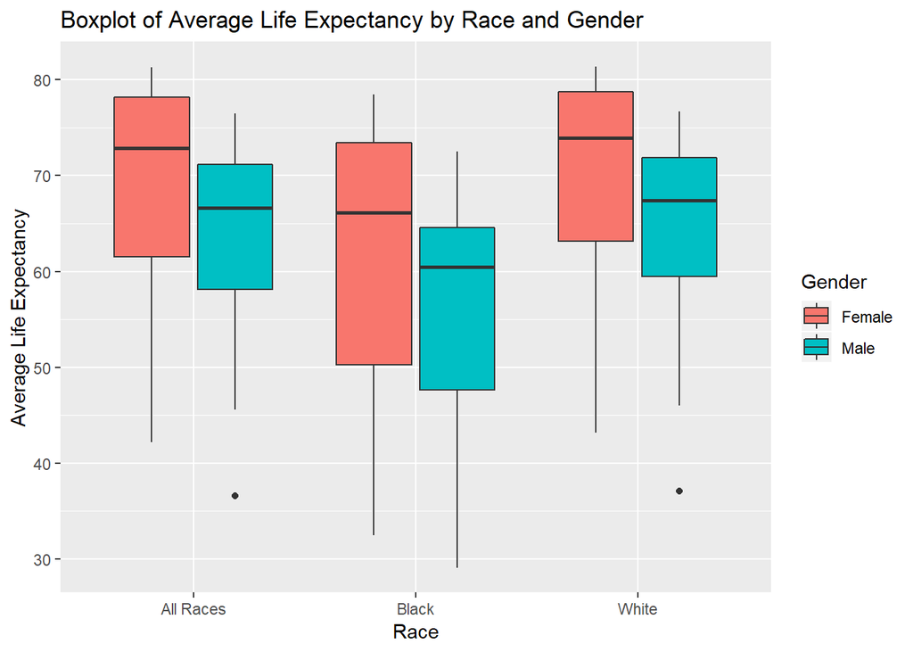

The line graph below tracks the difference in average life expectancy between males and females over time stratified by race. For all racial categories, this difference remains relatively small closer to the early part of this dataset. The life expectancy difference then grows considerably until the 1970s with a current downward trend since that point.

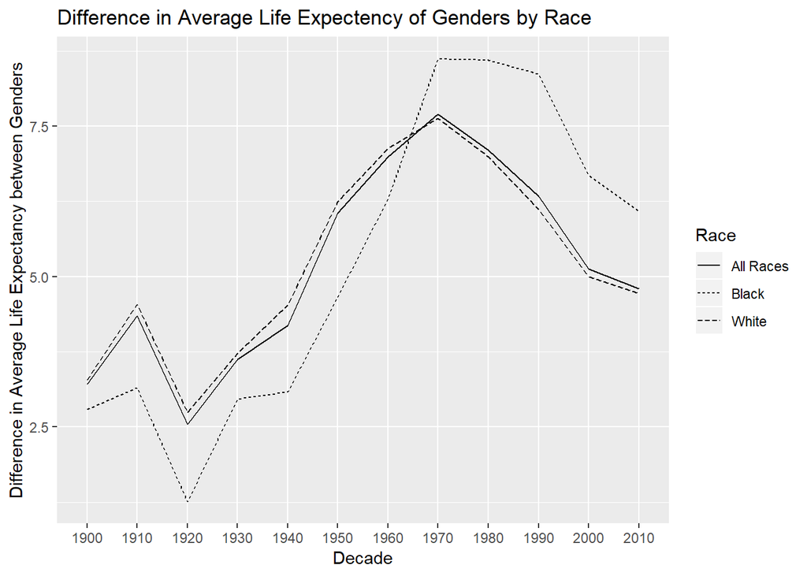

## Mortality rates

Similar to the upward trend in average life expectancy rates, the mortality rates for males and females in all racial categories has considerably decreased over time. As you can see from the faceted scatterplot below, mortality rates for blacks were considerably higher than whites from 1900 to the 1930s. Since the 1940s, although mortality rates for blacks of both sexes remained persistently higher than for whites, the difference is considerably less.

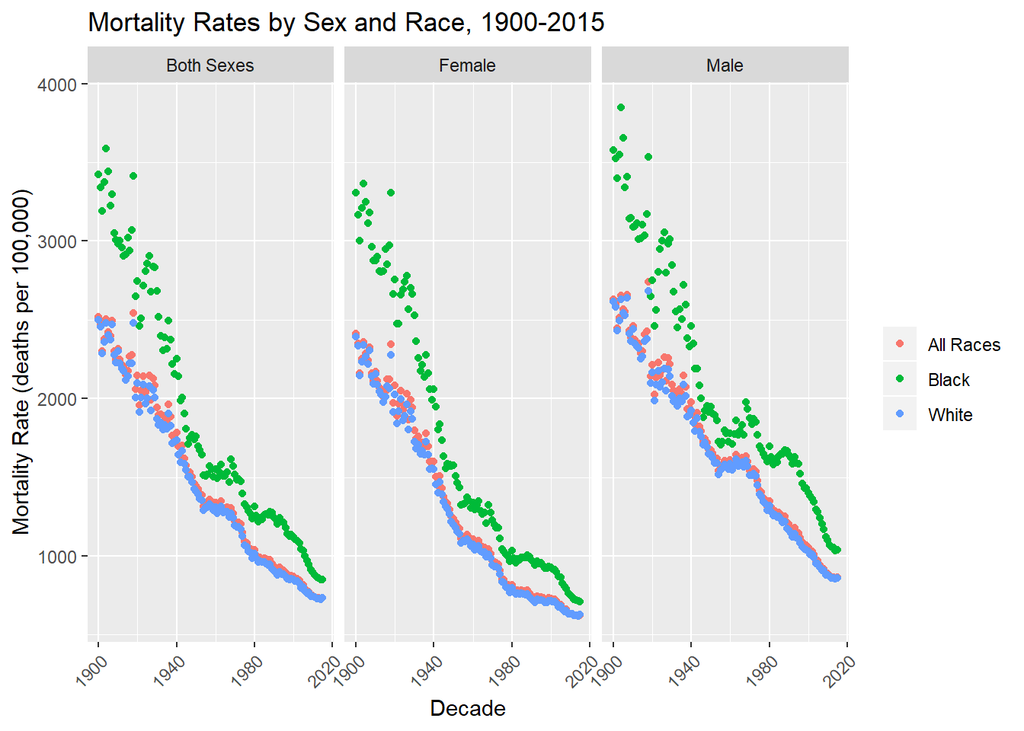